# Regresión lineal múltiple

Daniel Hernan Freire Navarrete

2 de agosto de 2015

### Introducción

Se quiere realizar una regresión multiple de la data Poblacion , para asi poder interpretar los resultados y poder dar las conclusiones deacuerdo a los resultados obtenidos, además de detallar los pasos realizados para realizar nuestra regresión multilineal.

### Realización de la regresión lineal multiple.

Primero leemos las datas *poblacion1* y *poblacion2*, para esto cargamos primero *library(readxl)* luego unimos las datas *poblacion1* y *poblacion2* la cual llamaremos *poblacion*, todo esto se realizo con las siguientes lineas de codigo

```r
library(readxl)
poblacion1 <- read_excel("poblacion1.xlsx",sheet = 1,col_names = TRUE,na = "")
poblacion2 <- read_excel("poblacion2.xlsx",sheet = 1,col_names = TRUE,na = "")
poblacion <- merge(x = poblacion1,y = poblacion2, by = "identificador", suffixes = c("",""))
str(poblacion)
```

```
## 'data.frame':    40 obs. of  10 variables:
##  $ identificador  : num  1001 1002 1003 1004 1005 ...
##  $ poblacion      : num  18.7 13.8 13.4 11.4 10.5 10.3 10.3 10.3 10.3 9.4 ...
##  $ var.pobl.mayor : num  6.2 7.2 7.1 2.6 2.8 1.4 -0.5 3 -1.9 -1.5 ...
##  $ menores.18     : num  39.7 10.4 20.4 38.7 36.4 29.8 31.8 31.1 15.9 22.4 ...
##  $ part.almz.escl : num  55.8 57.9 13.9 78.2 72.3 43.7 57.2 51.7 39.9 22.2 ...
##  $ var.ingresos   : num  28.7 26.2 22.5 18.4 26 29.4 27.2 26.2 38.5 33.5 ...
##  $ tasa.crimen    : num  52.6 111 38.3 86.6 77.5 54 61.2 42.4 86.4 61.5 ...
##  $ var.tasa.crimen: num  -2.9 -22.6 -33.6 -12.8 -21.6 -10 -17.6 -31.9 -13.5 -32.7 ...
##  $ region         : chr  "A" "A" "A" "A" ...
##  $ serv.bas.compl : chr  "SI" "SI" "NO" "NO" ...
```

Analizando la data poblacion se tiene que la data disponemos de 40 observaciones de 10 variables.

Se requiere explicar la varible poblacion en función de los regresores identificador,var.pobl.mayor,menores.18,part.almz.escl,var.ingresos,tasa.crimen,var.tasa.crimen,region,serv.bas.compl. En lugar de utilizar la función `View(poblacion)` para vizualizar el conjunto de datos empleamos la función `datatable()` del paquete `DT()`, esta función permite crear un **HTML widget** . Se tiene la siguiente tabla,

```r
library(DT)
datatable(poblacion)
```

|  | identificador | poblacion | var.pobl.mayor | menores.18 | part.almz.escl | var.ingresos | tasa.crimen | var.tasa.crimen | region | serv.bas.compl |
| --- | --- | --- | --- | --- | --- | --- | --- | --- | --- | --- |
| 1 | 1001 | 18.7 | 6.2 | 39.7 | 55.8 | 28.7 | 52.6 | -2.9 | A | SI |
| 2 | 1002 | 13.8 | 7.2 | 10.4 | 57.9 | 26.2 | 111 | -22.6 | A | SI |
| 3 | 1003 | 13.4 | 7.1 | 20.4 | 13.9 | 22.5 | 38.3 | -33.6 | A | NO |
| 4 | 1004 | 11.4 | 2.6 | 38.7 | 78.2 | 18.4 | 86.6 | -12.8 | A | NO |
| 5 | 1005 | 10.5 | 2.8 | 36.4 | 72.3 | 26 | 77.5 | -21.6 | A | SI |
| 6 | 1006 | 10.3 | 1.4 | 29.8 | 43.7 | 29.4 | 54 | -10 | A | NO |
| 7 | 1007 | 10.3 | -0.5 | 31.8 | 57.2 | 27.2 | 61.2 | -17.6 | A | NO |
| 8 | 1008 | 10.3 | 3 | 31.1 | 51.7 | 26.2 | 42.4 | -31.9 | A | NO |
| 9 | 1009 | 10.3 | -1.9 | 15.9 | 39.9 | 38.5 | 86.4 | -13.5 | A | SI |
| 10 | 1010 | 9.4 | -1.5 | 22.4 | 22.2 | 33.5 | 61.5 | -32.7 | A | NO |

[output cut: 30 more lines]

### Modelo de regresión lineal múltiple

```r
reg<- lm(poblacion ~ var.pobl.mayor + menores.18  + tasa.crimen+part.almz.escl+var.ingresos+var.tasa.crimen, poblacion)
summary(reg)
```

```
##
## Call:
## lm(formula = poblacion ~ var.pobl.mayor + menores.18 + tasa.crimen +
##     part.almz.escl + var.ingresos + var.tasa.crimen, data = poblacion)
##
## Residuals:
##     Min      1Q  Median      3Q     Max
## -5.4555 -2.7500 -0.1884  1.7262 10.3631
##
## Coefficients:
##                   Estimate Std. Error t value Pr(>|t|)
## (Intercept)      4.929e+00  3.150e+00   1.565    0.127
## var.pobl.mayor   2.960e-03  8.601e-02   0.034    0.973
## menores.18       6.088e-02  1.063e-01   0.573    0.571
## tasa.crimen     -1.440e-02  8.959e-03  -1.607    0.117
## part.almz.escl   3.480e-06  3.881e-02   0.000    1.000
## var.ingresos     5.557e-02  9.734e-02   0.571    0.572
## var.tasa.crimen -4.676e-02  4.358e-02  -1.073    0.291
##
## Residual standard error: 3.524 on 33 degrees of freedom
## Multiple R-squared:  0.1987, Adjusted R-squared:  0.05303
## F-statistic: 1.364 on 6 and 33 DF,  p-value: 0.258
```

Ahora vemos que regresores son significativo y realizamos la regresion para los regresores significativos

```r
reg1<-step(reg,direction="backward")
```

```
## Start:  AIC=107.07
## poblacion ~ var.pobl.mayor + menores.18 + tasa.crimen + part.almz.escl +
##     var.ingresos + var.tasa.crimen
##
##                   Df Sum of Sq    RSS    AIC
## - part.almz.escl   1     0.000 409.83 105.07
## - var.pobl.mayor   1     0.015 409.84 105.08
## - var.ingresos     1     4.047 413.88 105.47
## - menores.18       1     4.076 413.91 105.47
## - var.tasa.crimen  1    14.298 424.13 106.45
## <none>                         409.83 107.07
## - tasa.crimen      1    32.088 441.92 108.09
##
## Step:  AIC=105.07
## poblacion ~ var.pobl.mayor + menores.18 + tasa.crimen + var.ingresos +
##     var.tasa.crimen
##
##                   Df Sum of Sq    RSS    AIC
## - var.pobl.mayor   1     0.015 409.84 103.08
## - var.ingresos     1     4.337 414.17 103.50
## - menores.18       1    10.073 419.90 104.05
## - var.tasa.crimen  1    18.011 427.84 104.80
## <none>                         409.83 105.07
## - tasa.crimen      1    54.693 464.52 108.08
##
## Step:  AIC=103.08
## poblacion ~ menores.18 + tasa.crimen + var.ingresos + var.tasa.crimen
##
##                   Df Sum of Sq    RSS    AIC
## - var.ingresos     1     4.475 414.32 101.51
## - menores.18       1    10.281 420.13 102.07
## - var.tasa.crimen  1    18.848 428.69 102.87
## <none>                         409.84 103.08
## - tasa.crimen      1    68.352 478.20 107.25
##
## Step:  AIC=101.51
## poblacion ~ menores.18 + tasa.crimen + var.tasa.crimen
##
##                   Df Sum of Sq    RSS    AIC
## - menores.18       1    10.902 425.22 100.55
## - var.tasa.crimen  1    20.296 434.61 101.42
## <none>                         414.32 101.51
## - tasa.crimen      1    66.885 481.20 105.50
##
## Step:  AIC=100.55
## poblacion ~ tasa.crimen + var.tasa.crimen
##
##                   Df Sum of Sq    RSS     AIC
## - var.tasa.crimen  1    14.351 439.57  99.877
## <none>                         425.22 100.549
## - tasa.crimen      1    83.257 508.48 105.702
##
## Step:  AIC=99.88
## poblacion ~ tasa.crimen
##
##               Df Sum of Sq    RSS     AIC
## <none>                     439.57  99.877
## - tasa.crimen  1    71.895 511.47 103.936
```

```r
summary(reg1)
```

```
##
## Call:
## lm(formula = poblacion ~ tasa.crimen, data = poblacion)
##
## Residuals:
##     Min      1Q  Median      3Q     Max
## -5.3876 -2.7857 -0.2703  2.0894 10.7389
##
## Coefficients:
##              Estimate Std. Error t value Pr(>|t|)
## (Intercept)  8.617002   0.773049  11.147 1.54e-13 ***
## tasa.crimen -0.012469   0.005002  -2.493   0.0171 *
## ---
## Signif. codes:  0 '***' 0.001 '**' 0.01 '*' 0.05 '.' 0.1 ' ' 1
##
## Residual standard error: 3.401 on 38 degrees of freedom
## Multiple R-squared:  0.1406, Adjusted R-squared:  0.118
## F-statistic: 6.215 on 1 and 38 DF,  p-value: 0.01714
```

Notamos que solo la variabre tasa.crimen es significativa para nuestro modelo.

El modelo esta dado por la ecuación $\hat{po} =8.6170024 -0.0124691 \hat{ta}$

### Interpretación

**Interpretación modelo:** Al igual que en regresión lineal simple, los coeficientes $\beta$ van a indicar el incremento (o disminución) en la población por el incremento unitario de la correspondiente variable explicativa. Por lo tanto, estos coeficientes van a tener las correspondientes unidades de medida. En este caso *Si tasa.crimen se incrementa en una unidad, entonces poblacion disminuye en promedio -0.0124691 unidades.*

**Interpretación $R^2$:** *El modelo de regresión lineal múltiple obtenido explica el 14.0566909350585 % de la variabilidad total.*

### Pruebas de hipótesis

$H_0: \beta_1 =0$ $H_1: \beta_1 \neq 0$

Se sabe que $t= 11.1467677$ es mayor que $t_{38}(\frac{\alpha}{2})= 2.0243942$ se rechaza $H_0: \beta_1=0$.

$H_0: \beta_2 =0$ $H_1: \beta_2 \neq 0$

Se sabe que $t= 2.4930289$ es mayor que $t_{38}(\frac{\alpha}{2})= 2.0243942$ se rechaza $H_0: \beta_2=0$.

### Análisis de varianza

Realizando la tabla **ANOVA** tenemos los siguientes resultados:

```r
anova <- aov(reg1)
summary(anova)[[1]]
```

```
##             Df Sum Sq Mean Sq F value  Pr(>F)
## tasa.crimen  1  71.90  71.895  6.2152 0.01714 *
## Residuals   38 439.57  11.568
## ---
## Signif. codes:  0 '***' 0.001 '**' 0.01 '*' 0.05 '.' 0.1 ' ' 1
```

### Intervalos de confianza

```r
confint(reg1,level = 0.95)
```

```
##                   2.5 %      97.5 %
## (Intercept)  7.05204569 10.18195920
## tasa.crimen -0.02259422 -0.00234391
```

```r
confint(reg1,level = 0.90)
```

```
##                     5 %         95 %
## (Intercept)  7.31367631  9.920328581
## tasa.crimen -0.02090149 -0.004036641
```

### Gráficos residuales

```r
(u_t <- reg1$residuals) #residuos
```

```
##            1            2            3            4            5
## 10.738870284  6.567063583  5.260562678  3.862818437  2.849349961
##            6            7            8            9           10
##  2.356326973  2.446104229  2.211685838  2.760324625  1.549844948
##           11           12           13           14           15
##  2.048607481  1.964817263  0.745856735  3.100015893  1.935157884
##           16           17           18           19           20
##  0.398474295  0.269795449  0.191249790 -0.717992421 -0.635696603
##           21           22           23           24           25
## -0.778091418 -0.005256985 -0.535439670 -2.025216926 -0.994272881
##           26           27           28           29           30
## -2.736439083 -1.969839181 -2.672580487 -3.111491516 -3.561624703
##           31           32           33           34           35
## -2.980813845 -2.933431404 -3.361615263 -2.327177993 -4.145414920
##           36           37           38           39           40
## -4.166612328 -3.799003574 -5.387562242 -4.273817954  1.862465045
```

```r
(y_t <- reg1$fitted.values) #prediccion
```

```
##         1         2         3         4         5         6         7
##  7.961130  7.232936  8.139437  7.537182  7.650650  7.943673  7.853896
##         8         9        10        11        12        13        14
##  8.088314  7.539675  7.850155  7.351393  7.335183  7.754143  5.399984
##        15        16        17        18        19        20        21
##  6.464842  7.801526  7.830205  7.408750  8.217992  8.135697  8.178091
##        22        23        24        25        26        27        28
##  7.305257  7.735440  7.825217  6.694273  7.836439  6.969839  6.872580
##        29        30        31        32        33        34        35
##  7.311492  7.761625  7.080814  7.033431  7.261615  6.027178  7.745415
##        36        37        38        39        40
##  7.766612  6.299004  7.887562  6.373818 -0.162465
```

```r
data <- data.frame(poblacion, y_t,u_t)
datatable(data,filter="top", options = list(
  searching = TRUE,
  pageLength = 5,
 lengthMenu = c(5, 10, 15)
 ))
```

|  | identificador | poblacion | var.pobl.mayor | menores.18 | part.almz.escl | var.ingresos | tasa.crimen | var.tasa.crimen | region | serv.bas.compl | y_t | u_t |
| --- | --- | --- | --- | --- | --- | --- | --- | --- | --- | --- | --- | --- |
| 1 | 1001 | 18.7 | 6.2 | 39.7 | 55.8 | 28.7 | 52.6 | -2.9 | A | SI | 7.96112971584769 | 10.7388702841523 |
| 2 | 1002 | 13.8 | 7.2 | 10.4 | 57.9 | 26.2 | 111 | -22.6 | A | SI | 7.23293641721664 | 6.56706358278336 |
| 3 | 1003 | 13.4 | 7.1 | 20.4 | 13.9 | 22.5 | 38.3 | -33.6 | A | NO | 8.13943732150563 | 5.26056267849437 |
| 4 | 1004 | 11.4 | 2.6 | 38.7 | 78.2 | 18.4 | 86.6 | -12.8 | A | NO | 7.53718156253509 | 3.86281843746491 |
| 5 | 1005 | 10.5 | 2.8 | 36.4 | 72.3 | 26 | 77.5 | -21.6 | A | SI | 7.65065003886288 | 2.84934996113712 |
| 6 | 1006 | 10.3 | 1.4 | 29.8 | 43.7 | 29.4 | 54 | -10 | A | NO | 7.94367302718187 | 2.35632697281813 |
| 7 | 1007 | 10.3 | -0.5 | 31.8 | 57.2 | 27.2 | 61.2 | -17.6 | A | NO | 7.85389577118626 | 2.44610422881374 |
| 8 | 1008 | 10.3 | 3 | 31.1 | 51.7 | 26.2 | 42.4 | -31.9 | A | NO | 8.08831416184146 | 2.21168583815854 |
| 9 | 1009 | 10.3 | -1.9 | 15.9 | 39.9 | 38.5 | 86.4 | -13.5 | A | SI | 7.53967537520164 | 2.76032462479836 |
| 10 | 1010 | 9.4 | -1.5 | 22.4 | 22.2 | 33.5 | 61.5 | -32.7 | A | NO | 7.85015505218645 | 1.54984494781355 |

[output cut: 30 more lines]

```r
library(ggplot2)
(u_t <- reg1$residuals)
```

```
##            1            2            3            4            5
## 10.738870284  6.567063583  5.260562678  3.862818437  2.849349961
##            6            7            8            9           10
##  2.356326973  2.446104229  2.211685838  2.760324625  1.549844948
##           11           12           13           14           15
##  2.048607481  1.964817263  0.745856735  3.100015893  1.935157884
##           16           17           18           19           20
##  0.398474295  0.269795449  0.191249790 -0.717992421 -0.635696603
##           21           22           23           24           25
## -0.778091418 -0.005256985 -0.535439670 -2.025216926 -0.994272881
##           26           27           28           29           30
## -2.736439083 -1.969839181 -2.672580487 -3.111491516 -3.561624703
##           31           32           33           34           35
## -2.980813845 -2.933431404 -3.361615263 -2.327177993 -4.145414920
##           36           37           38           39           40
## -4.166612328 -3.799003574 -5.387562242 -4.273817954  1.862465045
```

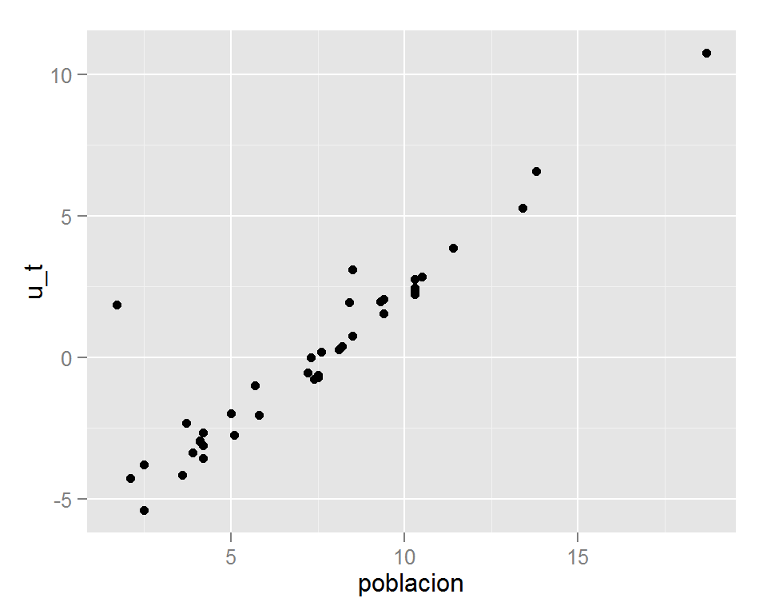

```r
g <- ggplot(data = poblacion, aes(x=poblacion, y=u_t))
g + geom_point()
```

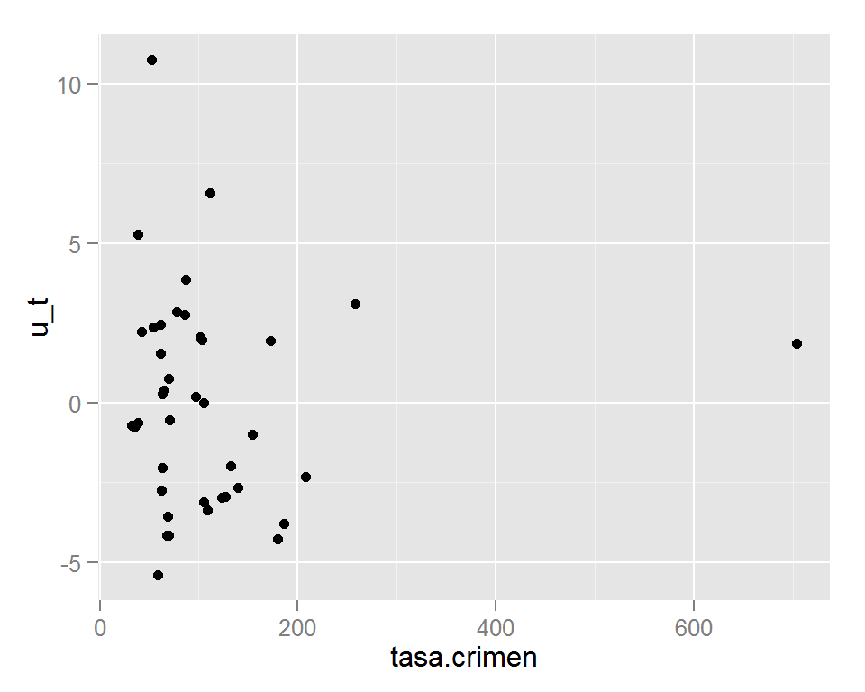

```r
g <- ggplot(data = poblacion, aes(x=tasa.crimen, y=u_t))
g + geom_point()
```

```r
#media de los residuos
mean(reg1$residuals)
```

```
## [1] 4.428153e-17
```

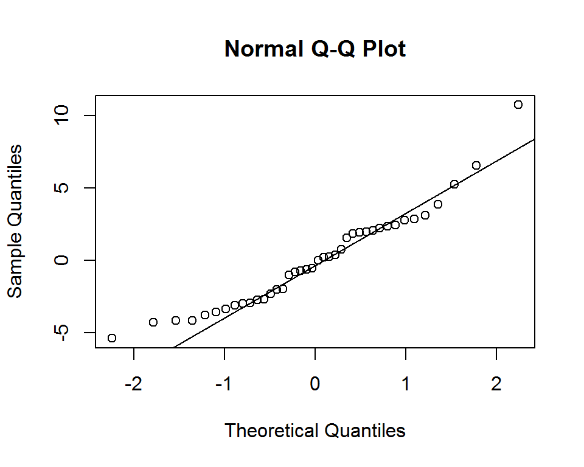

```r
# graf normal
qqnorm(u_t)
qqline(u_t)
```

```r
# Pronosticos vs residuos
(y_t <- reg1$fitted.values)
```

```
##         1         2         3         4         5         6         7
##  7.961130  7.232936  8.139437  7.537182  7.650650  7.943673  7.853896
##         8         9        10        11        12        13        14
##  8.088314  7.539675  7.850155  7.351393  7.335183  7.754143  5.399984
##        15        16        17        18        19        20        21
##  6.464842  7.801526  7.830205  7.408750  8.217992  8.135697  8.178091
##        22        23        24        25        26        27        28
##  7.305257  7.735440  7.825217  6.694273  7.836439  6.969839  6.872580
##        29        30        31        32        33        34        35
##  7.311492  7.761625  7.080814  7.033431  7.261615  6.027178  7.745415
##        36        37        38        39        40
##  7.766612  6.299004  7.887562  6.373818 -0.162465
```

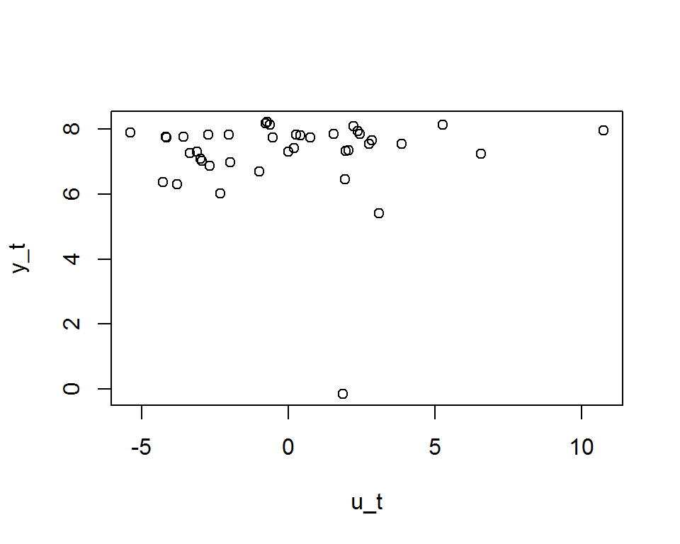

```r
plot(u_t,y_t)
```

```r
# Puntos singulares
library(car)
outlierTest(reg1) # Bonferonni p-value for most extreme obs
```

```
##   rstudent unadjusted p-value Bonferonni p
## 1 3.709958         0.00067788     0.027115
```

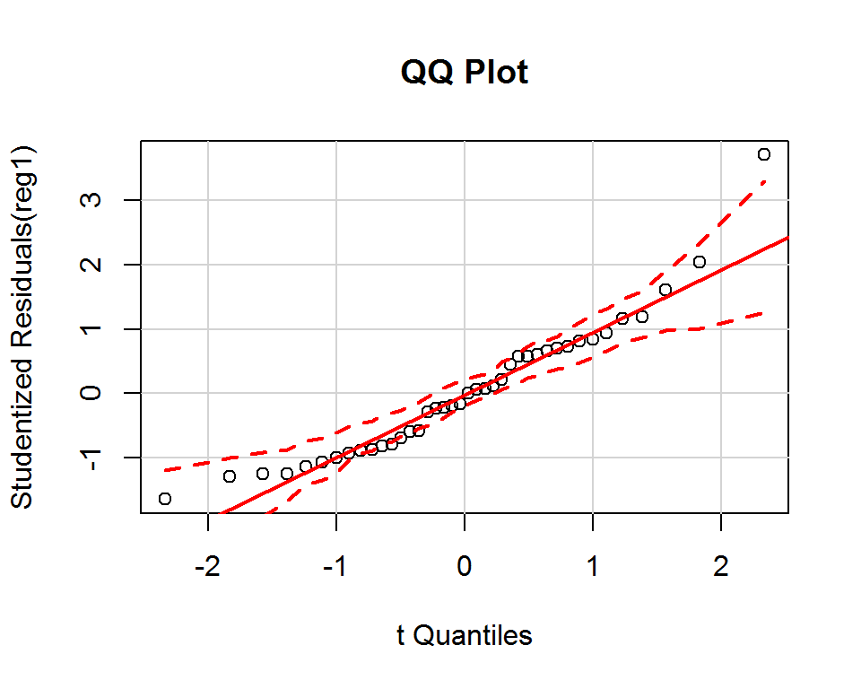

```r
qqPlot(reg1, main="QQ Plot") #qq plot for studentized residuo
```

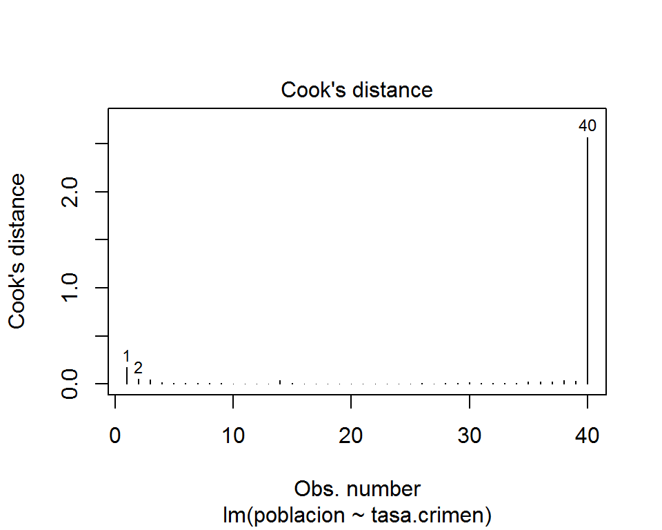

```r
# puntos influyentes
# Cook's plot
# D > 2/k
cutoff <- 2/((nrow(poblacion)-length(reg1$coefficients)))
plot(reg1, which=4, cook.levels=cutoff)
```

```r
poblacion[40,]
```

```
##    identificador poblacion var.pobl.mayor menores.18 part.almz.escl
## 40          1044       1.7           32.2        7.5           73.8
##    var.ingresos tasa.crimen var.tasa.crimen region serv.bas.compl
## 40         50.5       704.1           -40.9      B             SI
```

### Conclusiones

De los resultados obtenidos de la regresion lineal múltiple se puede asegurar que la variabilidad esta dada en 14.0566909350585 %. Existen observaciones influyentes en los parámetros de la regresión. Se conclye tambien que nuestra regresión es significante puesto que el p-valor es menor que 0.05. Ademas se notó que nuestra variable o regresor significativo fue unicamente tasa.crimen.